# 混合图

庄闪闪

2020-11-24

## 前言

在同一页面上混合多个图形是一种常见的做法。它可以在同一数字上 总结大量信息，例如，它被广泛用于科学出版物。

## 基础包——par()

一页多图用mfrow参数或mfcol参数规定，这也是我几年前经常用的一种方法。

```r
x <- rnorm(50)
y <- rnorm(50,2,2)
```

随便模拟产生数据，并对数据绘制一些简单的图，用该函数将一页中对他们进行全部展示。

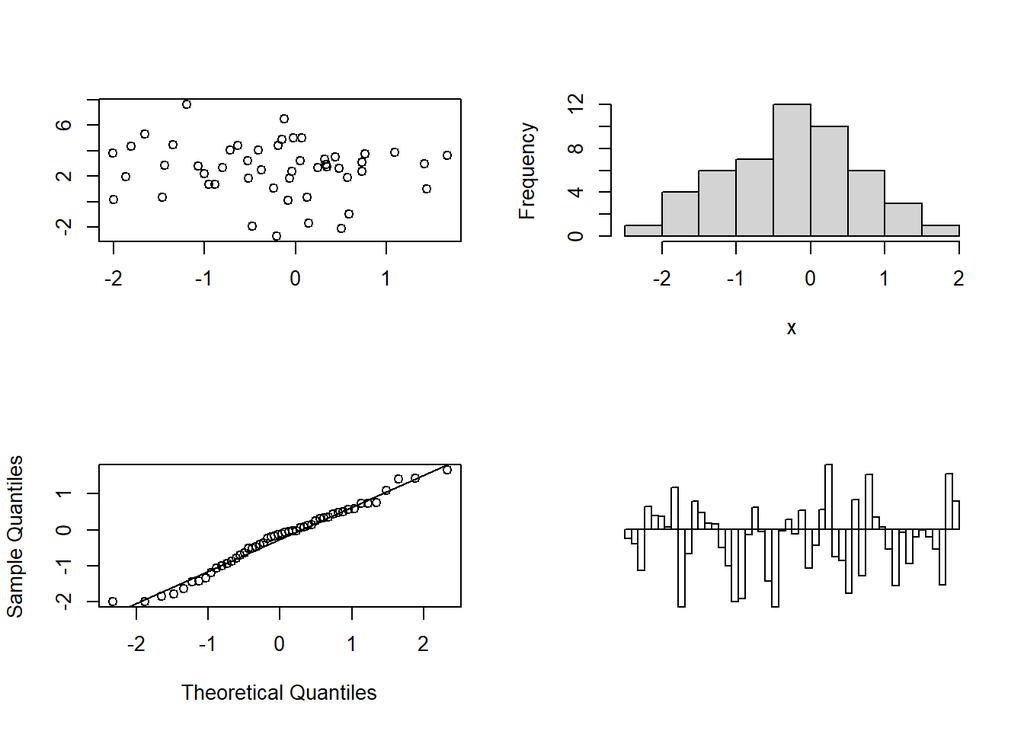

```r
par(mfrow=c(2,2))
plot(x, y, xlab = "", ylab = "")
hist(x,main='')
qqnorm(x,main = '');qqline(x)
barplot(x, axes = FALSE, space = 0,col='white')
```

## 基础包——layout()

```
layout(mat, widths = rep.int(1, ncol(mat)),
       heights = rep.int(1, nrow(mat)), respect = FALSE)
```

- mat 参数为一个矩阵，提供了作图的顺序以及图形版面的安排。0代表空缺，不绘制图形，大于0 的数代表绘图顺序，相同数字代表占位符。
- widths 和 heights 参数提供了各个矩形作图区域的长和宽的比例。
- respect 参数控制着各图形内的横纵轴刻度长度的比例尺是否一样。
- n 参数为欲显示的区域的序号。

生成2行2列的版面，并设置宽度和高度。par()中oma参数指四个外边空的行数

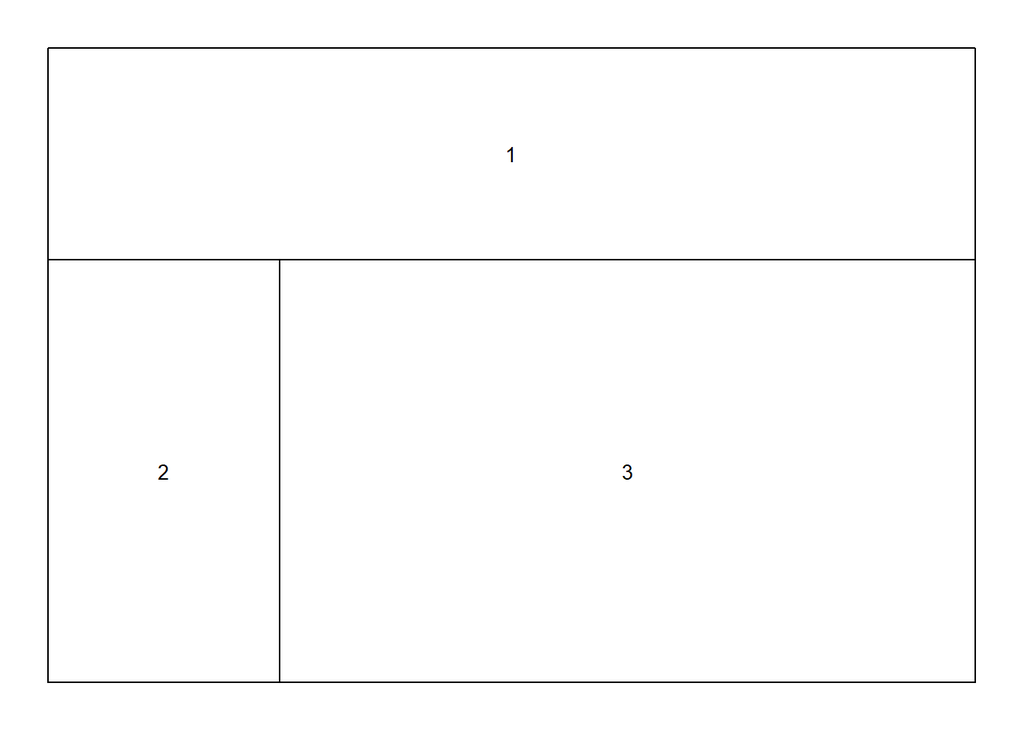

```r
par(oma = c(2,2,2,2))
nf <- layout(matrix(c(1,2,1,3),2,2),widths = c(1, 3), heights = c(1, 2))
layout.show(nf)
```

再将各个图进行填充

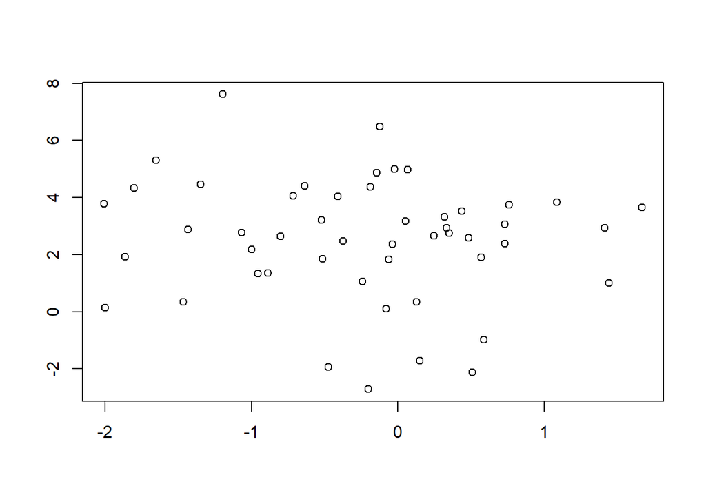

```r
plot(x, y, xlab = "", ylab = "")
```

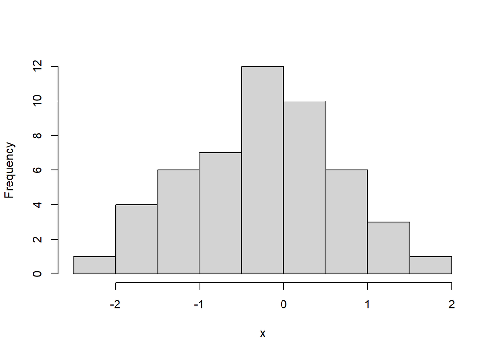

```r
hist(x,main='')
```

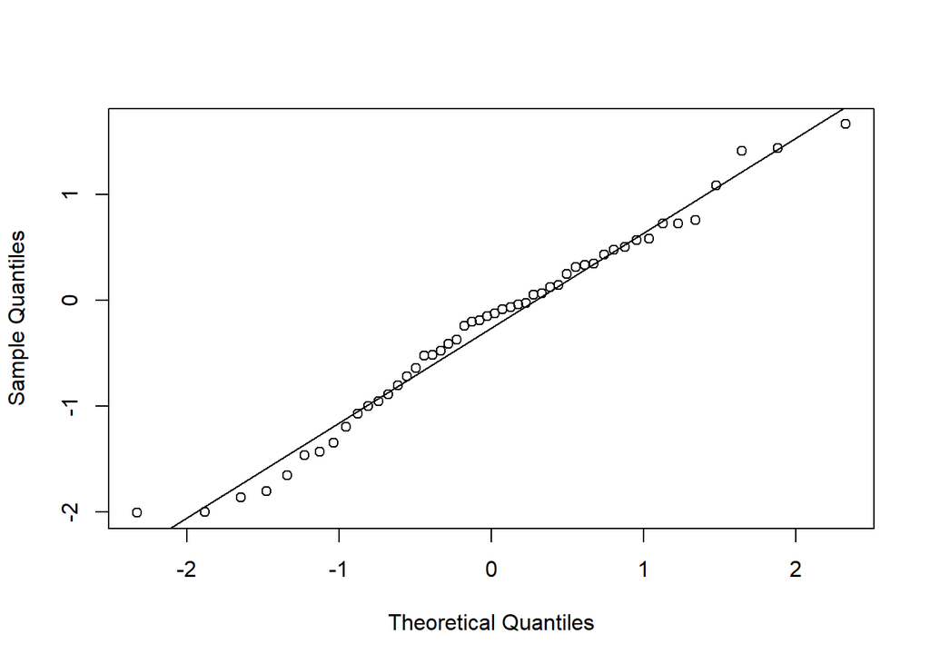

```r
qqnorm(x,main = '');qqline(x)
```

前面两种方法，说实话可以实现，但是比较费劲。那么下面看看gridExtra包。

## gridExtra包——混合多个图形

gridExtra包让混合多个图片变得轻而易举。它提供了grid.arrange() 函数来完成这个任务。它的nrow参数允许指定如何安排布局。

```r
library(ggplot2)
library(gridExtra)
```

这里我们用ggplot绘图，并存在变量名称（g1,g2,g3）中，然后用grid.arrange()将各个变量名称展现出来。

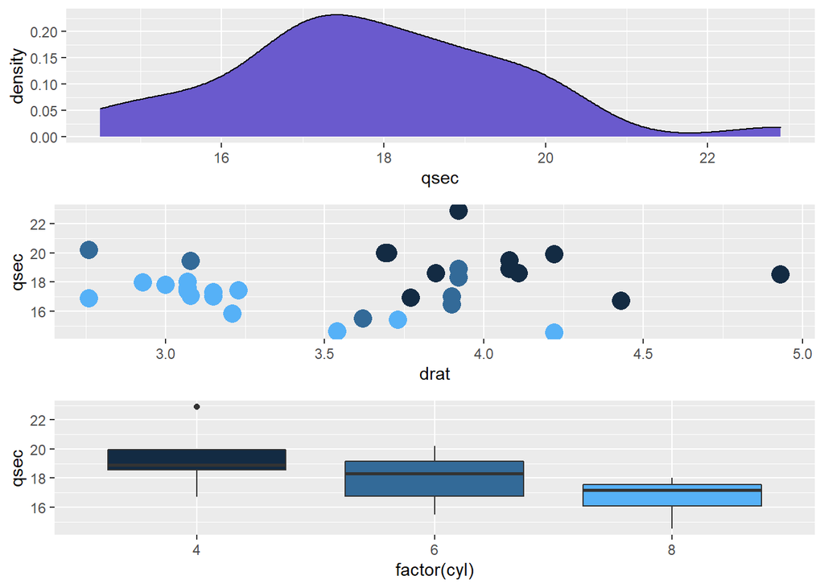

```r
# Make 3 simple graphics:
g1 <- ggplot(mtcars, aes(x=qsec)) + geom_density(fill="slateblue")
g2 <- ggplot(mtcars, aes(x=drat, y=qsec, color=cyl)) + geom_point(size=5) + theme(legend.position="none")
g3 <- ggplot(mtcars, aes(x=factor(cyl), y=qsec, fill=cyl)) + geom_boxplot() + theme(legend.position="none")
g4 <- ggplot(mtcars , aes(x=factor(cyl), fill=factor(cyl))) + geom_bar()
# Plots
grid.arrange(g1, g2, g3, nrow = 3)
```

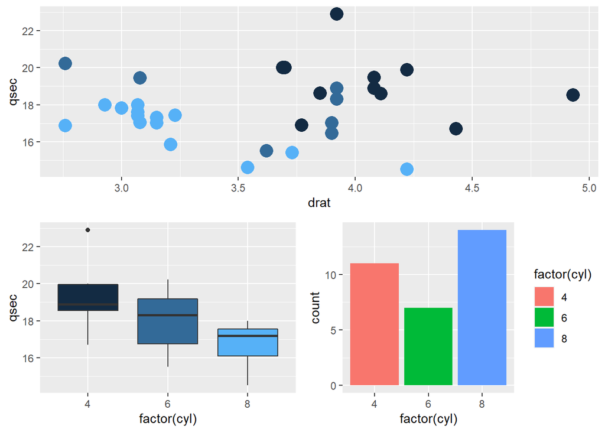

```r
grid.arrange(g2, arrangeGrob(g3, g4, ncol=2), nrow = 2)
```

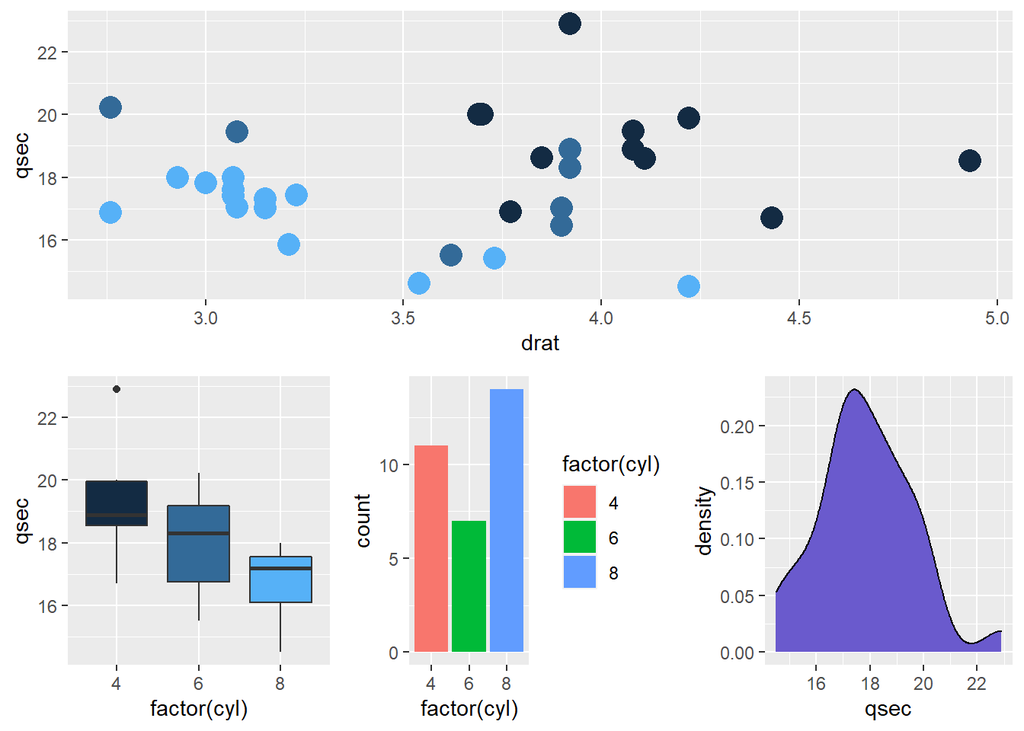

```r
grid.arrange(g2, arrangeGrob(g3, g4,g1, ncol=3), nrow = 2)
```